# Tarea modulo 3

Lo primero es identificar y seleccionar el entorno donde trabajamos.

```r
getwd()
```

```
## [1] "/Users/eduardoinigo/Documents/Master big data/ejerciciosR/students"
```

```r
setwd("/Users/eduardoinigo/Documents/Master Big data/ejerciciosR/students")
```

Cargamos las librerias necesarias para el proceso.

```r
library("ggplot2")
library("corrplot")
library("dplyr")
library("plotrix")
library("knitr")
library("mlbench")
library("caret")
library("ROCR")
library("e1071")
```

# Exploratorio

Carga de datos.

```r
stmat<-read.table("./student/student-mat.csv",row.names=NULL,sep=";",header=TRUE)
head(stmat)
```

```
##   school sex age address famsize Pstatus Medu Fedu     Mjob     Fjob
## 1     GP   F  18       U     GT3       A    4    4  at_home  teacher
## 2     GP   F  17       U     GT3       T    1    1  at_home    other
## 3     GP   F  15       U     LE3       T    1    1  at_home    other
## 4     GP   F  15       U     GT3       T    4    2   health services
## 5     GP   F  16       U     GT3       T    3    3    other    other
## 6     GP   M  16       U     LE3       T    4    3 services    other
##       reason guardian traveltime studytime failures schoolsup famsup paid
## 1     course   mother          2         2        0       yes     no   no
## 2     course   father          1         2        0        no    yes   no
## 3      other   mother          1         2        3       yes     no  yes
## 4       home   mother          1         3        0        no    yes  yes
## 5       home   father          1         2        0        no    yes  yes
## 6 reputation   mother          1         2        0        no    yes  yes
##   activities nursery higher internet romantic famrel freetime goout Dalc
## 1         no     yes    yes       no       no      4        3     4    1
## 2         no      no    yes      yes       no      5        3     3    1
## 3         no     yes    yes      yes       no      4        3     2    2
## 4        yes     yes    yes      yes      yes      3        2     2    1
## 5         no     yes    yes       no       no      4        3     2    1
## 6        yes     yes    yes      yes       no      5        4     2    1
##   Walc health absences G1 G2 G3
## 1    1      3        6  5  6  6
## 2    1      3        4  5  5  6
## 3    3      3       10  7  8 10
## 4    1      5        2 15 14 15
## 5    2      5        4  6 10 10
## 6    2      5       10 15 15 15
```

```r
str(stmat)
```

```
## 'data.frame':    395 obs. of  33 variables:
##  $ school    : Factor w/ 2 levels "GP","MS": 1 1 1 1 1 1 1 1 1 1 ...
##  $ sex       : Factor w/ 2 levels "F","M": 1 1 1 1 1 2 2 1 2 2 ...
##  $ age       : int  18 17 15 15 16 16 16 17 15 15 ...
##  $ address   : Factor w/ 2 levels "R","U": 2 2 2 2 2 2 2 2 2 2 ...
##  $ famsize   : Factor w/ 2 levels "GT3","LE3": 1 1 2 1 1 2 2 1 2 1 ...
##  $ Pstatus   : Factor w/ 2 levels "A","T": 1 2 2 2 2 2 2 1 1 2 ...
##  $ Medu      : int  4 1 1 4 3 4 2 4 3 3 ...
##  $ Fedu      : int  4 1 1 2 3 3 2 4 2 4 ...
##  $ Mjob      : Factor w/ 5 levels "at_home","health",..: 1 1 1 2 3 4 3 3 4 3 ...
##  $ Fjob      : Factor w/ 5 levels "at_home","health",..: 5 3 3 4 3 3 3 5 3 3 ...
##  $ reason    : Factor w/ 4 levels "course","home",..: 1 1 3 2 2 4 2 2 2 2 ...
##  $ guardian  : Factor w/ 3 levels "father","mother",..: 2 1 2 2 1 2 2 2 2 2 ...
##  $ traveltime: int  2 1 1 1 1 1 1 2 1 1 ...
##  $ studytime : int  2 2 2 3 2 2 2 2 2 2 ...
```

[output cut: 19 more lines]

Empezamos con la limpieza de los datos.

```r
names(stmat)<-tolower(names(stmat))

stmat$mjob<-gsub("_"," ",stmat$mjob)
```

A priorio no parece que tengamos más datos que limpiar ya que están bien definidos, sin embargo antes de realizar un análisis explotarioro conviene ver si tenemos las variables más evidentes relacionadas con las notas como por ejemplo el tiempo libre, las ausencias, etc.

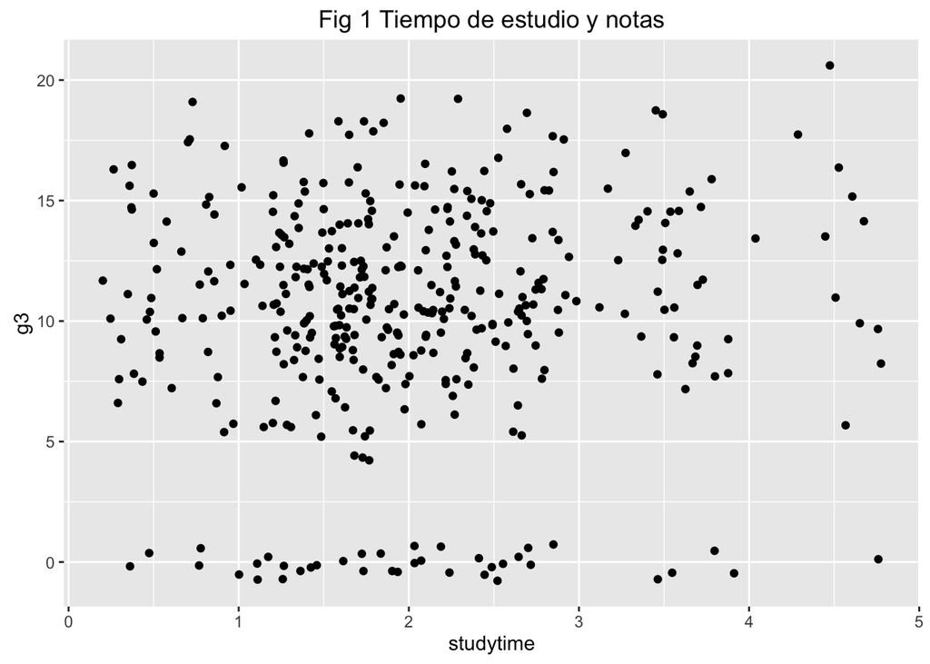

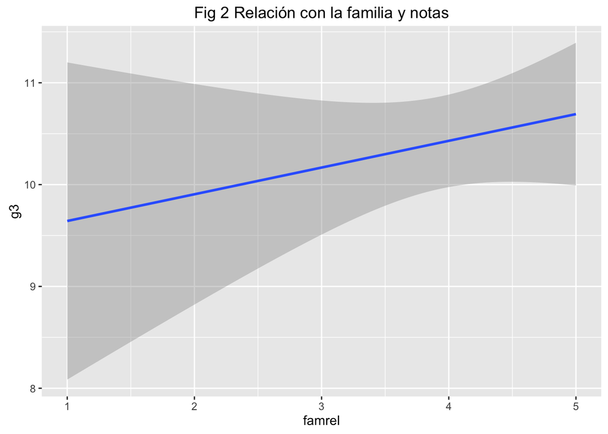

Parece ser que el tiempo de estudio no tiene mucho que ver con las notas finales, por el contrario la relación con la familia influye directamente en las notas, vamos a ver si pasa lo mismo con los padres divorciados o no.

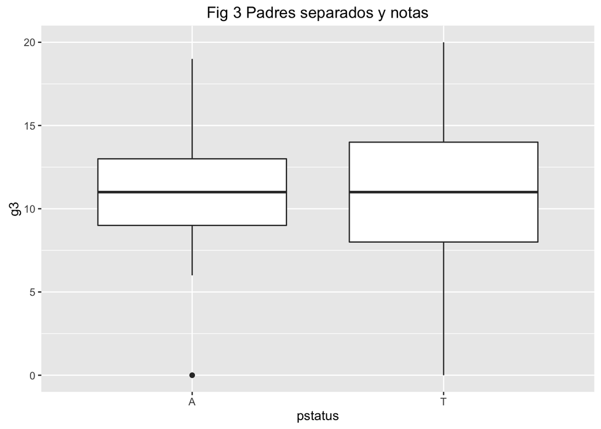

```r
ggplot(stmat,aes(x=pstatus,y=g3))+geom_boxplot()+ggtitle("Fig 3 Padres separados y notas")
```

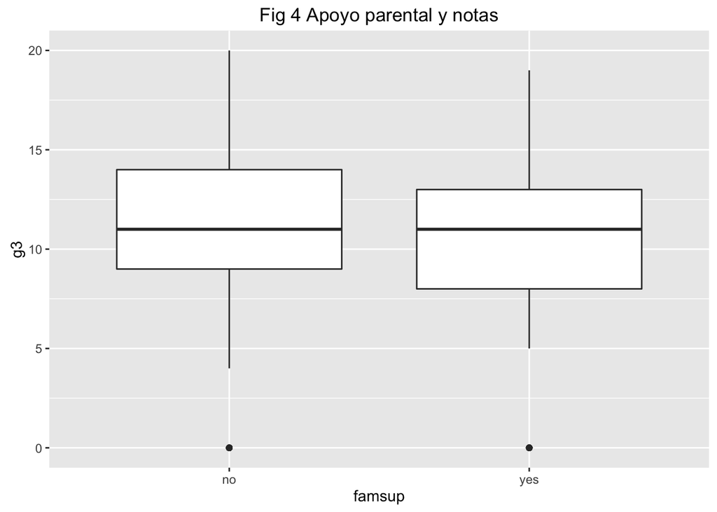

```r
ggplot(stmat,aes(x=famsup,y=g3))+geom_boxplot()+ggtitle("Fig 4 Apoyo parental y notas")
```

Como se observa no parece que haya relación directa entre el estado civil de los padres, el apoyo que les dan y las notas, vamos a proceder a realizar una matriz de correlación entre variables para determinar cuales de las variables tienen mayor relación entre sí.

Transformamos algunas variables para poder introducirlas en la matriz.

[figure not shown]

```r
stmat$address<-ifelse(stmat$address =="U",1,0)
stmat$famsize<-ifelse(stmat$famsize=="GT3",1,0)
stmat$pstatus<-ifelse(stmat$pstatus=="T",1,0)
stmat$schoolsup<-ifelse(stmat$schoolsup=="yes",1,0)
stmat$famsup<-ifelse(stmat$famsup=="yes",1,0)
stmat$paid<-ifelse(stmat$paid=="yes",1,0)
stmat$activities<-ifelse(stmat$activities=="yes",1,0)
stmat$higher<-ifelse(stmat$higher=="yes",1,0)
stmat$internet<-ifelse(stmat$internet=="yes",1,0)
stmat$romantic<-ifelse(stmat$romantic=="yes",1,0)
stmat$nursery<-ifelse(stmat$nursery=="yes",1,0)
stmat$school<-ifelse(stmat$school=="GP",1,0)
stmat$sex<-ifelse(stmat$sex=="M",1,0)

stcor<-cor(stmat[,c("address","famsize","pstatus","medu","fedu","traveltime","studytime","failures","schoolsup","famsup","paid","activities","higher","internet","romantic","famrel","freetime","goout","absences","g1","g2","g3")])

col <- colorRampPalette(c("#BB4444", "#EE9988", "#FFFFFF", "#77AADD", "#4477AA"))
corrplot(stcor, method = "shade", shade.col = NA, tl.col = "black",tl.srt = 45, col = col(200), addCoef.col="black",order="AOE",mar = c(1,0,2,0), line=-2,main = "Fig 5 Matriz de correlación")
```

# Modelo de aprendizaje no supervisado.

Para el modelo de aprendizaje no supervisado optamos por los clustering y ver como agrupa las variables. Los otros modelos de aprendizaje no supervisado no parecen ser adecuados para el problema en cuestión.

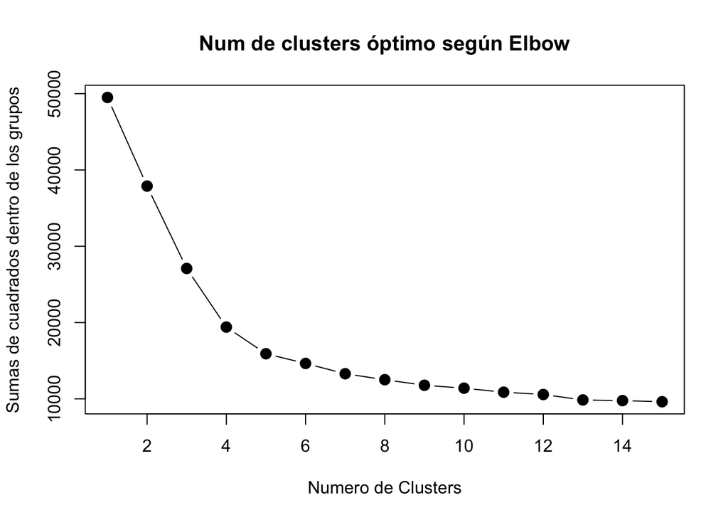

```r
mydata <- select(stmat,-mjob,-fjob,-reason,-guardian)
wss <- (nrow(mydata)-1)*sum(apply(mydata,2,var))
  for (i in 2:15) wss[i] <- sum(kmeans(mydata,
                                       centers=i)$withinss)
plot(1:15, wss, type="b", xlab="Numero de Clusters",
     ylab="Sumas de cuadrados dentro de los grupos",
     main="Num de clusters óptimo según Elbow",
     pch=20, cex=2)
```

Parece que el número optimo de clusters es 5.

```r
set.seed(1234)
kmeans.clust<-kmeans(mydata,5)
kmeans.clust
```

```
## K-means clustering with 5 clusters of sizes 5, 127, 152, 39, 72
##
## Cluster means:
##      school       sex      age   address   famsize   pstatus     medu
## 1 1.0000000 0.2000000 17.80000 0.6000000 0.8000000 0.8000000 3.000000
## 2 0.8976378 0.5826772 16.40945 0.8346457 0.6771654 0.9055118 3.015748
## 3 0.8486842 0.4342105 16.58553 0.7171053 0.7236842 0.9078947 2.539474
## 4 0.8974359 0.3846154 17.02564 0.7179487 0.8205128 0.9487179 2.282051
## 5 0.9166667 0.4305556 17.18056 0.8472222 0.6805556 0.8333333 2.958333
##       fedu traveltime studytime   failures  schoolsup    famsup      paid
## 1 3.000000   1.400000  2.000000 0.40000000 0.20000000 0.6000000 0.4000000
## 2 2.748031   1.338583  2.141732 0.05511811 0.03937008 0.5748031 0.4803150
## 3 2.394737   1.546053  2.039474 0.31578947 0.22368421 0.6250000 0.5000000
## 4 2.256410   1.589744  1.974359 0.94871795 0.05128205 0.6153846 0.2051282
## 5 2.500000   1.361111  1.875000 0.52777778 0.12500000 0.6527778 0.4722222
```

[output cut: 42 more lines]

```r
table(stmat$g3,kmeans.clust$cluster)
```

```
##
##       1  2  3  4  5
##   0   0  0  0 38  0
##   4   0  0  0  0  1
##   5   0  0  1  1  5
##   6   0  0 11  0  4
##   7   0  0  7  0  2
##   8   2  0 19  0 11
##   9   1  0 18  0  9
##   10  0  0 48  0  8
##   11  2  2 32  0 11
##   12  0 12 13  0  6
##   13  0 17  3  0 11
##   14  0 26  0  0  1
##   15  0 32  0  0  1
##   16  0 16  0  0  0
##   17  0  6  0  0  0
##   18  0 10  0  0  2
##   19  0  5  0  0  0
##   20  0  1  0  0  0
```

```r
stmat$clusterid<-kmeans.clust$cluster
mydata$clusterid<-kmeans.clust$cluster
```

Se puede observar que en los clusters se agrupan rango de notas, en el 2 los de notas altas, en el 3 de aprobados justos y en el 4 los suspensos con nota muy baja.

# Modelo de aprendizaje supervisado con caret.

Modelo de aprendizaje supervisado con caret. Utilizamos los datos de mydata ya que estos no contienen los valores de las profesiones de los padres ni tampoco la supervisión, los cuales se pueden eliminar.

```r
set.seed(1111)
index.mydata <- createDataPartition(mydata$g3, p=0.7, list=F)

train.mydata <- mydata[index.mydata,]
test.mydata <- mydata[ -index.mydata, ]

#fitControl <- trainControl(method = "none")
fitControl <- trainControl(method="cv", repeats=10)

lm.model.caret <- train(g3 ~. ,data = train.mydata ,method = "lm", trControl = fitControl)
print(lm.model.caret)
```

```
## Linear Regression
##
## 279 samples
##  29 predictor
##
## No pre-processing
## Resampling: Cross-Validated (10 fold)
## Summary of sample sizes: 251, 251, 252, 250, 249, 252, ...
## Resampling results:
##
##   RMSE      Rsquared
##   2.054835  0.8040973
##
## Tuning parameter 'intercept' was held constant at a value of TRUE
##
```

```r
summary(lm.model.caret$finalModel)
```

```
##
## Call:
## lm(formula = .outcome ~ ., data = dat)
##
## Residuals:
##     Min      1Q  Median      3Q     Max
## -8.0694 -0.5269  0.2409  1.0256  3.7522
##
## Coefficients:
##              Estimate Std. Error t value Pr(>|t|)
## (Intercept)  0.502237   2.423813   0.207 0.836016
## school      -0.322403   0.443990  -0.726 0.468430
## sex          0.149418   0.283142   0.528 0.598168
## age         -0.202769   0.114281  -1.774 0.077234 .
## address      0.161284   0.352854   0.457 0.648009
## famsize     -0.125526   0.268555  -0.467 0.640613
## pstatus     -0.199885   0.417814  -0.478 0.632781
## medu         0.106798   0.147771   0.723 0.470527
## fedu        -0.166594   0.145036  -1.149 0.251809
## traveltime   0.038054   0.180682   0.211 0.833361
## studytime   -0.051120   0.157094  -0.325 0.745147
## failures    -0.237766   0.179726  -1.323 0.187071
## schoolsup    0.717690   0.401056   1.790 0.074749 .
## famsup       0.112858   0.265055   0.426 0.670629
## paid         0.140665   0.270184   0.521 0.603090
## activities  -0.372251   0.250674  -1.485 0.138808
## nursery     -0.297539   0.304577  -0.977 0.329570
## higher       0.035507   0.615688   0.058 0.954057
## internet    -0.148277   0.364948  -0.406 0.684874
## romantic    -0.319614   0.263938  -1.211 0.227064
## famrel       0.404714   0.148621   2.723 0.006924 **
## freetime     0.009588   0.134232   0.071 0.943115
## goout        0.181161   0.132977   1.362 0.174317
## dalc        -0.076159   0.186759  -0.408 0.683778
## walc         0.186300   0.141411   1.317 0.188901
## health       0.052553   0.091222   0.576 0.565068
## absences     0.056187   0.016292   3.449 0.000661 ***
## g1           0.191933   0.075125   2.555 0.011219 *
## g2           0.936646   0.070917  13.208  < 2e-16 ***
## clusterid   -0.259340   0.140572  -1.845 0.066242 .
## ---
## Signif. codes:  0 '***' 0.001 '**' 0.01 '*' 0.05 '.' 0.1 ' ' 1
##
## Residual standard error: 1.941 on 249 degrees of freedom
## Multiple R-squared:  0.8361, Adjusted R-squared:  0.817
## F-statistic: 43.79 on 29 and 249 DF,  p-value: < 2.2e-16
```

Prediccion y evaluación del modelo

```r
lm.model.caret.predict <- predict(lm.model.caret$finalModel, newdata = test.mydata)
print(head(lm.model.caret.predict))
```

```
##         5         7         9        11        21        24
##  9.053251 11.866836 18.790152  7.336425 13.667055 14.025977
```

```r
test.values.lm <-data.frame(obs=test.mydata$g3,pred=lm.model.caret.predict)
defaultSummary(test.values.lm)
```

```
##      RMSE  Rsquared
## 1.7781465 0.8601291
```

Random forest para la regresión

```r
tunegrid <- expand.grid(mtry=c(1))
rf.reg.model <- train(g3 ~. ,data = train.mydata ,method = "rf", tuneGrid = tunegrid, trControl = fitControl)
print(rf.reg.model)
```

```
## Random Forest
##
## 279 samples
##  29 predictor
##
## No pre-processing
## Resampling: Cross-Validated (10 fold)
## Summary of sample sizes: 251, 252, 251, 251, 250, 252, ...
## Resampling results:
##
##   RMSE      Rsquared
##   3.250387  0.7388101
##
## Tuning parameter 'mtry' was held constant at a value of 1
##
```

```r
rf.reg.model.predict <- predict(rf.reg.model$finalModel, newdata = test.mydata)
print(head(rf.reg.model.predict))
```

```
##         5         7         9        11        21        24
##  9.579550 11.399429 12.685857  9.649867 12.610016 11.478058
```

```r
test_values_rf<-data.frame(obs=test.mydata$g3,pred=rf.reg.model.predict)
defaultSummary(test_values_rf)
```

```
##      RMSE  Rsquared
## 3.3367008 0.7701864
```

Comparamos ambos modelos de prediccion, lm y randomForest

```r
reg.models <- list( lm.model.caret, rf.reg.model )
compar.reg.models <- resamples( reg.models )
summary( compar.reg.models )
```

```
##
## Call:
## summary.resamples(object = compar.reg.models)
##
## Models: Model1, Model2
## Number of resamples: 10
##
## RMSE
##         Min. 1st Qu. Median  Mean 3rd Qu.  Max. NA's
## Model1 1.606   1.890  1.944 2.055   2.135 2.958    0
## Model2 2.544   3.063  3.316 3.250   3.469 3.987    0
##
## Rsquared
##          Min. 1st Qu. Median   Mean 3rd Qu.   Max. NA's
## Model1 0.6061  0.7748 0.8224 0.8041  0.8738 0.9087    0
## Model2 0.6065  0.7232 0.7559 0.7388  0.7742 0.8423    0
```

El modelo con regresión lineal parece más preciso.